# Integration of omics and clinical data of the hormonal, metabolic, inflammatory, and oxidative response in the different macronutrients of the diet

Statistical Descriptive analysis of Intestinal Permeability Biomarkers

Edmond Geraud

16 de noviembre, 2021

```r
> list.of.packages <- c("xlsx", "kableExtra", "dplyr", "ggplot2", "egg", "cowplot",
+     "patchwork", "gridExtra", "UsingR", "car", "lattice", "ggpubr", "ggbreak", "GGally",
+     "reshape2", "ggcorrplot", "corrplot", "rela", "ggrepel", "factoextra", "chemometrics",
+     "sparsepca")
> new.packages <- list.of.packages[!(list.of.packages %in% installed.packages()[, "Package"])]  ## check for packages not installed
> if (length(new.packages)) install.packages(new.packages)  ## install packages if necessary
> res <- unlist(lapply(list.of.packages, require, character.only = T))  ## load packages needed for the session
> if (any(res == F)) {
+     list.of.packages[which(res == F)]  ## show those package if you have troubles to install.
+ }
>
> list.of.bioc.packages <- c("phyloseq", "pcaMethods")
> new.packages.bioc <- list.of.packages[!(list.of.bioc.packages %in% installed.packages()[,
+     "Package"])]
> if (length(new.packages.bioc)) BiocManager::install(new.packages.bioc)
> res.bioc <- unlist(lapply(list.of.bioc.packages, require, character.only = T))
> if (any(res.bioc == F)) {
+     list.of.packages[which(res.bioc == F)]  ## show those package if you have troubles to install.
+ }
```

```r
> resumen <- function(x) {
+     c(round(mean(x), 4), round(sd(x), 4))
+ }  # Function that help us to summarize the data in mean and sd values
> lowerFn <- function(data, mapping, method = "lm", ...) {
+     p <- ggplot(data = data, mapping = mapping) + geom_point(colour = "blue") + geom_smooth(method = method,
+         color = "red", ...)
+     p
+ }
>
>
> plotPCA_scores <- function(X, factor, title, size = 1.5, glineas = 0.25, center_,
+     scale_, labels) {
+
+
+     pcX <- prcomp(X, center = center_, scale. = scale_)
+     X.scores <- pcX$x
+     rot <- round(pcX$sdev^2/sum(pcX$sdev^2) * 100, 2)
+
+     # scores
+     X.scores <- as.data.frame(X.scores)
+     Group <- factor[[1]]
+     Group2 <- factor[[2]]
+     colores <- 1:length(levels(Group))
+     # main plot
+     p1 <- ggplot(X.scores, aes(x = PC1, y = PC2)) + theme_classic() + geom_hline(yintercept = 0,
+         color = "gray70") + geom_vline(xintercept = 0, color = "gray70") + geom_point(aes(color = Group,
+         shape = Group2), alpha = 0.55, size = 3) + coord_cartesian(xlim = c(min(X.scores[,
+         1]) - 5, max(X.scores[, 1]) + 5)) + scale_fill_discrete(name = "Group")
+     # avoiding labels superposition
+
+     grafico <- p1 + geom_text_repel(aes(y = PC2 + 0.25, label = labels), segment.size = 0.25,
+         size = size) + labs(x = c(paste("PC1", rot[1], "%")), y = c(paste("PC2",
+         rot[2], "%"))) + ggtitle(paste("Principal Component Analysis for: ", title,
+         sep = " ")) + theme(plot.title = element_text(hjust = 0.5)) + scale_color_manual(values = colores)
+
+
+
+     return(list(pcX, grafico))
+ }
>
> plotPCA_nipals <- function(pcX, factor, title, size = 1.5, glineas = 0.25, labels,
+     plot.scores = T) {
+
+     X.scores <- scores(pcX)
+     X.loads <- loadings(pcX)
+     rot <- round(sDev(pcX)/sum(sDev(pcX)) * 100, 2)
+     if (plot.scores == T) {
+         # scores
+         X.scores <- as.data.frame(X.scores)
+         Group <- factor[[1]]
+         Group2 <- factor[[2]]
+         colores <- 1:length(levels(Group))
+         # main plot
+         p1 <- ggplot(X.scores, aes(x = PC1, y = PC2)) + theme_classic() + geom_hline(yintercept = 0,
+             color = "gray70") + geom_vline(xintercept = 0, color = "gray70") + geom_point(aes(color = Group,
+             shape = Group2), alpha = 0.55, size = 3) + coord_cartesian(xlim = c(min(X.scores[,
+             1]), max(X.scores[, 1]))) + scale_fill_discrete(name = "Group")
+         # avoiding labels superposition
+
+         grafico <- p1 + geom_text_repel(aes(y = PC2 + 0.25, label = labels), segment.size = 0.25,
+             size = size) + labs(x = c(paste("PC1", rot[1], "%")), y = c(paste("PC2",
+             rot[2], "%"))) + ggtitle(paste("Principal Component Analysis for: ",
+             title, sep = " ")) + theme(plot.title = element_text(hjust = 0.5)) +
+             scale_color_manual(values = colores)
+     } else {
+
+         X.loads <- as.data.frame(X.loads)
+         # main plot
+         p1 <- ggplot(X.loads, aes(x = PC1, y = PC2)) + theme_classic() + geom_hline(yintercept = 0,
+             color = "gray70") + geom_vline(xintercept = 0, color = "gray70") + geom_point(aes(color = "gray70"),
+             alpha = 0.55, size = 3) + coord_cartesian(xlim = c(min(X.loads[, 1]),
+             max(X.loads[, 1])))
+         # avoiding labels superposition
+
+         grafico <- p1 + geom_text_repel(aes(label = labels), segment.size = 0.25,
+             size = size) + labs(x = c(paste("PC1", rot[1], "%")), y = c(paste("PC2",
+             rot[2], "%"))) + ggtitle(paste("Principal Component Analysis for: ",
+             title, sep = " ")) + theme(plot.title = element_text(hjust = 0.5))
+
+     }
+
+     return(list(pcX, grafico))
+ }
> plotPCA_methods <- function(X.list, factor, title1, title2, size = 1.5, glineas = 0.25,
+     labels.scores, labels.loads) {
+
+     X.scores <- X.list$scores
+     X.loadings <- X.list$loadings
+     colnames(X.scores) <- paste0("PC", 1:dim(X.scores)[2])
+
+     colnames(X.loadings) <- paste0("PC", 1:dim(X.loadings)[2])
+     varianza <- as.data.frame(X.list$var)
+     varianza$PC <- paste0("PC", 1:dim(X.loadings)[2])
+     colnames(varianza) <- c("varianza", "PC")
+     # scores
+     X.scores <- as.data.frame(X.scores)
+     Group <- factor[[1]]
+     Group2 <- factor[[2]]
+     colores <- 1:length(levels(Group))
+     # main plot
+     p1 <- ggplot(X.scores, aes(x = PC1, y = PC2)) + theme_classic() + geom_hline(yintercept = 0,
+         color = "gray70") + geom_vline(xintercept = 0, color = "gray70") + geom_point(aes(color = Group,
+         shape = Group2), alpha = 0.55, size = 3) + coord_cartesian(xlim = c(min(X.scores[,
+         1]), max(X.scores[, 1]))) + scale_fill_discrete(name = "Group")
+     # avoiding labels superposition
+
+     grafico <- p1 + geom_text_repel(aes(y = PC2, label = labels.scores), segment.size = 0.25,
+         size = size) + labs(x = c(paste("PC1", round(varianza[1, 1], 2), "%")), y = c(paste("PC2",
+         round(varianza[2, 1], 2), "%"))) + ggtitle(paste("Principal Component Analysis for: ",
+         title1, sep = " ")) + theme(plot.title = element_text(hjust = 0.5)) + scale_color_manual(values = colores)
+
+     X.loadings <- as.data.frame(X.loadings)
+     # main plot
+     p2 <- ggplot(X.loadings, aes(x = PC1, y = PC2)) + theme_classic() + geom_hline(yintercept = 0,
+         color = "gray70") + geom_vline(xintercept = 0, color = "gray70") + geom_point(aes(color = "gray70"),
+         alpha = 0.55, size = 3) + coord_cartesian(xlim = c(min(X.loadings[, 1]),
+         max(X.loadings[, 1])))
+     # avoiding labels superposition
+
+     grafico2 <- p2 + geom_text_repel(aes(label = labels.loads), segment.size = 0.25,
+         size = size) + labs(x = c(paste("PC1", round(varianza[1, 1], 2), "%")), y = c(paste("PC2",
+         round(varianza[2, 1], 2), "%"))) + ggtitle(paste("Principal Component Analysis for: ",
+         title2, sep = " ")) + theme(plot.title = element_text(hjust = 0.5)) + theme(legend.position = "none")
+
+     graficos <- list(grafico, grafico2)
+     return(graficos)
+ }
```

# Summary of the univariate descrpitve analysis.

## Overall study.

The data comprises 53 subjects, which are divided into 34 females and 19 males. From the 34 females, 18 are non obese and 16 obese. And 10 non obese males and 9 obese males. The 18 non obese females are divided into 9 PCOS and 9 healthy. The 16 obese females are divided further into 8 PCOS and 8 non PCOS.

For each numerical variable (all except the ones that describes the groups) their distribution were analyzed as a whole, without taking into account the groups (obese, sex and PCOS).

It has to be mentioned that no correlation between variables on the different data types were performed. Only uni variate statistical analysis on each data set was performed.

Permeability markers, and some clinical biomarkers, were analyzed at basal and postprandial times. The first day of the study corresponds to the glucose oral load, the second to the lipids and the third to the proteins.

1. **Clinical data:** Comprises 63 variables. The first variable is the order of the data, the second variable is the sample name, and the next 5 variables belong to sex, group (female, male, PCOS), obese (whether obese or not obese), age and BMI, WC, WHR. And 54 biomarkers. From those 54 biomarkers, there are testosterone, estradiol, its ratio, HOMA-IR, ISI, cholesterol, HDL , LDL, insulin and glucose. Sex steroids, the ratio, HOMA-IR and ISI are only calculated at basal levels. The other variables are calculated also at postprandial level. Furthemore the levels of all these variables the mean basal value for each day of the study is computed.
2. **Permability Biomarkers:** Apart from the categorical variables, we have sCD14, LBP, zonulin and succinate. Each variable the mean basal value is computed,as well as the basal values for each day and the postprandial stage. Succinate is more like a metabolite, however, it was calculated in other units, and we do not know how to include this metablolite. ( No units are specified on this data set)
3. **Metabolome:** The data includes only the sample and the order. And 261 variables. From these variables, only 37 were actually metabolites. The other variables belong to the mean basal values, the basal values for each day, and the postprandial values for each day.

## Description of gut microbiome

First of all, let’s inspect if the study is compromised by these subjects. We are going to perform chisq-test to observe if there are differences between groups.

```r
> general <- file.path(params$folder.data, params$general.data)
> general_data <- read.xlsx(general, sheetIndex = 1)  ## data
> general_data$SEX <- factor(general_data$SEX, levels = c(0, 2), labels = c("Female",
+     "Male"))
> general_data$OBESE <- factor(general_data$OBESE, levels = c(0, 1), labels = c("No Obese",
+     "Obese"))
> general_data$GROUP <- factor(general_data$GROUP, levels = c(0, 1, 2), labels = c("Female",
+     "PCOS", "Male"))
> GROUP <- general_data$GROUP
> OBESE <- general_data$OBESE
> bacteria_file <- file.path(params$folder.data, params$file.data)
> bacteria_phylum.tmp <- (read.xlsx(bacteria_file, sheetIndex = 2))
> bacteria_genera.tmp <- read.xlsx(bacteria_file, sheetIndex = 4)
> str(bacteria_phylum.tmp)
```

```
'data.frame':   46 obs. of  25 variables:
 $ Order                      : num  2 3 4 5 6 7 8 9 10 11 ...
 $ Sample                     : chr  "Md3" "Md4" "Md5" "Md6" ...
 $ Firmicutes                 : num  68.3 58.5 95 55.9 93.4 ...
 $ Bacteroidetes              : num  28.622 29.659 0.189 27.201 0.236 ...
 $ Proteobacteria             : num  0.929 3.568 0.506 0.174 0.74 ...
 $ Actinobacteria             : num  0.219 7.218 3.329 15.629 5.107 ...
 $ Verrucomicrobia            : num  1.49453 0.34982 0.57235 0.00238 0.06314 ...
 $ Candidatus.Saccharibacteria: num  0.0087 0.01208 0.04649 0.00476 0.02611 ...
 $ Chlamydiae                 : num  0 0 0 0 0 0 0 0 0 0 ...
 $ Chloroflexi                : num  0 0 0 0 0 0 0 0 0 0 ...
 $ Cyanobacteria.Chloroplast  : num  0.0029 0.00173 0 0.00357 0.00285 ...
 $ Elusimicrobia              : num  0 0 0 0 0 ...
 $ Euryarchaeota              : num  0 0 0.00349 0 0.05649 ...
 $ Fusobacteria               : num  0 0.00115 0.00407 0.00952 0.02943 ...
 $ Gemmatimonadetes           : num  0 0 0 0 0 0 0 0 0 0 ...
 $ Lentisphaerae              : num  0 0.0023 0 0 0 ...
 $ Nitrospirae                : num  0 0 0 0 0 0 0 0 0 0 ...
 $ Parcubacteria              : num  0 0 0 0 0 0 0 0 0 0 ...
 $ Spirochaetes               : num  0 0 0 0 0 0 0 0 0 0 ...
 $ FSR1                       : num  0 0 0 0 0 0 0 0 0 0 ...
 $ Synergistetes              : num  0 0.0069 0 0 0.0109 ...
 $ Tenericutes                : num  0 0 0 0 0 0 0 0 0 0 ...
 $ ud.Archaea                 : num  0.0512 0.1047 0.043 0.0155 0.0299 ...
 $ ud.Bacteria                : num  0.368 0.541 0.331 1.048 0.269 ...
 $ NA.                        : num  100 100 100 100 100 100 100 100 100 100 ...
```

### Process phylum data and sanity check.

First of all let’s process the phylum data. To do that, we need to find out which variables belong to each group. (OBESE and GROUP) Furthermore we have to transpose the data

```r
> ## which samples are in bacteria
> variables_in_bacteria <- general_data[general_data$Orden %in% bacteria_phylum.tmp$Order,
+     ]
> ## add categorical variables.
> bacteria_phylum.tmp$SEX <- variables_in_bacteria$SEX
> bacteria_phylum.tmp$GROUP <- variables_in_bacteria$GROUP
> bacteria_phylum.tmp$OBESE <- variables_in_bacteria$OBESE
```

```r
> (sexo <- table(bacteria_phylum.tmp$SEX))
```

```
Female   Male
    31     15
```

```r
> (sexo.obesos <- table(bacteria_phylum.tmp$SEX, bacteria_phylum.tmp$OBESE))
```

```
         No Obese Obese
  Female       15    16
  Male          8     7
```

```r
> (subgrupos <- table(bacteria_phylum.tmp$GROUP, bacteria_phylum.tmp$OBESE))
```

```
         No Obese Obese
  Female        8     8
  PCOS          7     8
  Male          8     7
```

```r
> chisq.test(sexo.obesos)
```

```
    Pearson's Chi-squared test with Yates' continuity correction

data:  sexo.obesos
X-squared = 0, df = 1, p-value = 1
```

```r
> chisq.test(subgrupos)
```

```
    Pearson's Chi-squared test

data:  subgrupos
X-squared = 0.13333, df = 2, p-value = 0.9355
```

There are no differences between groups, thus we can continue our exploratory analysis without concern. After the sanity check analysis, previously we have observed from the `str` function, that tells us the general structure of the data, that some variables are all 0. Thus we are going to remove those variables, and the unknown general.

```r
> zero_variables <- apply(bacteria_phylum.tmp, 2, function(x) all(x == 0))  ## which phylum have zero reads
> unkown_variables <- grep("ud", colnames(bacteria_phylum.tmp))  ## which phylum is unkwoun
> bacteria_phylum.tmp2 <- bacteria_phylum.tmp[, -c(zero_variables, unkown_variables)]  ## remove unkowns and zero reads
> rownames(bacteria_phylum.tmp2) <- bacteria_phylum.tmp2[, 1]
> bacteria_phylum.tmp3 <- bacteria_phylum.tmp2[, -c(1, 22)]
> zeros <- which(colSums(bacteria_phylum.tmp3[, -c(21:23)]) == 0)
> bacteria_phylum <- bacteria_phylum.tmp3[, -zeros]
> bacteria_phylum
```

```
     Firmicutes Bacteroidetes Proteobacteria Actinobacteria Verrucomicrobia
Md3    68.30362   28.62224972    0.929005066      0.2194424    1.494528e+00
Md4    58.53466   29.65944201    3.568407910      7.2179422    3.498213e-01
Md5    94.97438    0.18942695    0.506106986      3.3294983    5.723483e-01
Md6    55.91280   27.20079012    0.173730931     15.6286442    2.379876e-03
Md7    93.42888    0.23641223    0.740093710      5.1070739    6.313821e-02
Md8    83.59565    1.72009036    0.158720784     10.8779105    6.496479e-02
Md9    43.70427   21.44813954    4.586699957      6.1888084    2.376808e+01
Md10   89.29474    0.50765528    0.591590316      6.6531157    7.078858e-02
MO1    70.98188   13.17440544    0.402038505      8.9852775    6.221971e+00
MO2    70.40966   23.82699311    0.442175967      2.7204012    2.184296e+00
MO3    72.07830   25.75591909    0.759073132      1.1827663    1.051348e-03
MO4    87.12286    1.79381321    0.639194310      9.8914048    2.288892e-01
MO6    58.69852   30.57930573    2.020314767      8.3156602    0.000000e+00
MO7    85.80551    8.76936770    1.844954675      2.1837005    8.641474e-04
MO8    89.75287    0.31392138    0.286424619      6.5602695    3.002876e+00
MO9    75.72830   18.61583006    0.906100955      4.3983846    1.874045e-03
Pd1    74.31768   20.67668485    3.045081842      1.5112628    2.865242e-02
Pd2    58.41286   21.70471755    0.383604309      3.8031831    1.211961e+01
Pd3    64.45416   26.50868728    1.997480569      3.7953082    2.852185e-03
Pd4    79.11744   16.65060967    0.864713427      1.6289475    3.073486e-01
Pd6    95.97860    0.04728761    0.004298873      2.9533260    3.685307e-01
Pd8    60.82236   30.90073188    2.533735917      1.6479543    2.814176e+00
Pd11   60.04634   35.70941051    0.385568714      0.4777699    2.674434e+00
PO2    92.92374    0.05880434    0.034235403      6.6513346    4.954064e-02
PO3    76.44431   20.67577783    0.529847859      1.8872947    1.419552e-03
PO4    61.94224    2.98619203   20.122599929     14.3534233    2.307896e-02
PO5    52.49681   33.34375607    2.354412622      0.3008510    1.082134e+01
PO7    83.53355   14.15293316    0.090392224      1.1371080    6.995572e-01
PO8    75.86331   15.45457166    0.719185979      3.0561801    3.254353e+00
PO10   84.15552   10.85291720    1.052104530      3.5010239    2.310907e-02
PO11   73.98229    5.05704338    0.312071712     19.1669445    2.778086e-03
Vd1    57.64860   36.73388198    1.063590132      2.1669630    2.075415e+00
Vd3    85.89725    7.16058086    1.864101022      4.5569218    2.059704e-01
Vd4    81.72747   13.64120879    0.192857143      4.2159341    1.098901e-03
Vd5    74.47167   16.75153321    4.753206731      3.4388808    1.908222e-01
Vd6    67.43340   29.04573164    1.258925354      2.0023678    3.014950e-02
Vd7    47.41513   24.77428065    0.158917672     27.6263606    0.000000e+00
Vd9    73.53647   23.74257274    1.116555943      1.4509198    0.000000e+00
Vd10   77.59942   19.24395737    0.347934245      0.6846629    1.912798e+00
```

[output cut: 180 more lines]

```
Vd1  No Obese
Vd3  No Obese
Vd4  No Obese
Vd5  No Obese
Vd6  No Obese
Vd7  No Obese
Vd9  No Obese
Vd10 No Obese
VO1     Obese
VO2     Obese
VO3     Obese
VO4     Obese
VO5     Obese
VO6     Obese
VO8     Obese
```

```r
> phylum.variables <- bacteria_phylum  ## remove samples names and order from the summary
>
>
> phylum.sum <- phylum.variables %>%
+     group_by(GROUP, OBESE) %>%
+     summarise(across(where(is.numeric), resumen), n = n()) %>%
+     mutate_if(is.numeric, format, 4)  # Group the data by variable GROUP and OBESE
>
> d.f <- as.data.frame(t(phylum.sum))[c(nrow(t(phylum.sum)), 1:(nrow(t(phylum.sum)) -
+     1)), ]  # transpose the data for visualization purposes and get rid off the N value for same purposes
>
> # name of each variable.
> nombre_phylum_variable <- colnames(bacteria_phylum)[-c(21:23)]
>
> colnames(d.f) <- rep(c("Mean", "SD"), 6)
> d.f_final <- d.f[-c(1:3), ]
> ## ATTENION! Because assining left hand expression is complicated, just for one
> ## table, be careful if we put another data-set For showing the number of
> ## subjects by group
> as.data.frame(d.f_final)
```

```
                               Mean      SD    Mean      SD    Mean      SD
Firmicutes                  73.4686 19.4854 76.3222 10.5519 70.4499 13.6843
Bacteroidetes               13.6980 14.1474 15.3537 11.2163 21.7426 11.5428
Proteobacteria               1.4068  1.6908  0.9125  0.6621  1.3164  1.1970
Actinobacteria               6.9028  4.6793  5.5297  3.3605  2.2597  1.2734
Verrucomicrobia              3.2983  8.2859  1.4552  2.2555  2.6165  4.3640
Candidatus.Saccharibacteria  0.0229  0.0167  0.0913  0.1010  0.0156  0.0122
Chloroflexi                       0       0       0       0       0       0
Cyanobacteria.Chloroplast    0.0057  0.0074  0.0047  0.0079  0.0313  0.0707
Elusimicrobia                 3e-04   8e-04       0       0       0       0
Euryarchaeota                0.1892  0.3911  0.1687  0.3794  0.4592  0.6478
Fusobacteria                 0.0058  0.0101  0.0065  0.0111   7e-04   8e-04
Lentisphaerae                 3e-04   8e-04       0       0   3e-04   8e-04
Nitrospirae                       0       0       0       0       0       0
Parcubacteria                     0       0       0       0       0       0
FSR1                              0       0       0       0   1e-04   3e-04
Synergistetes                0.0188  0.0463       0       0  0.0514  0.1045
Tenericutes                       0       0       0       0       0       0
                               Mean      SD    Mean      SD    Mean      SD
Firmicutes                  75.1677 12.8644 70.7162 12.7930 75.6603 12.9987
Bacteroidetes               12.8227 10.7925 21.3867  9.2557 13.6272  7.5690
Proteobacteria               3.1519  6.8972  1.3445  1.5001  4.2092  7.0686
Actinobacteria               6.2568  6.8764  5.7679  8.9340  5.7817  3.6947
Verrucomicrobia              1.8594  3.7896  0.5520  0.8951  0.0603  0.0827
Candidatus.Saccharibacteria  0.0759  0.1135  0.0303  0.0227  0.0424  0.0295
Chloroflexi                       0       0   1e-04   4e-04       0       0
Cyanobacteria.Chloroplast    0.0042  0.0048  0.0257  0.0508  0.0045  0.0063
Elusimicrobia                     0       0       0       0       0       0
Euryarchaeota                0.0368  0.0769  0.0028  0.0075  0.4065  0.6099
Fusobacteria                 0.0012  0.0016  0.0039  0.0069  0.0022  0.0028
Lentisphaerae                0.0005  0.0015       0       0       0       0
Nitrospirae                       0       0       0       0   1e-04   2e-04
Parcubacteria                     0       0       0       0   3e-04   8e-04
FSR1                              0       0       0       0       0       0
Synergistetes                0.0199  0.0538  0.0030  0.0085  0.0004  0.0012
Tenericutes                       0       0   3e-04   8e-04   3e-04   8e-04
```

```r
> kbl(d.f_final, digits = c(rep(4, 12), 0)) %>%
+     kable_classic_2() %>%
+     add_header_above(c(` ` = 1, `9` = 2, `8` = 2, `9` = 2, `8` = 2, `10` = 2, `9` = 2)) %>%
+     add_header_above(c(` ` = 1, `No Obese` = 2, Obese = 2, `No Obese` = 2, Obese = 2,
+         `No Obese` = 2, Obese = 2)) %>%
+     add_header_above(c(` ` = 1, `Control Females` = 4, PCOS = 4, `Control Males` = 4))
```

[output not shown]

```r
> (p <- ncol(bacteria_phylum))
```

```
[1] 20
```

```r
> (n <- nrow(bacteria_phylum))
```

```
[1] 46
```

We proceed to observe the distribution of the relativa abundance.

```r
> variables <- colnames(bacteria_phylum)
> hist.list.meta <- list()  ## initizalize a list of the histogram
> ## plot all histograms via loop
> for (i in 1:length(variables)) {
+     if (variables[i] == "Order" || variables[i] == "Sample") {
+         next
+     } else if (class(bacteria_phylum[, i]) == "factor") {
+         next
+     }
+     variable <- variables[i]  ## name of the variable to plot
+     titulo <- colnames(bacteria_phylum)[i]  # title of the varialbe
+
+     breaks <- pretty(range(bacteria_phylum[, variable]), n = nclass.Sturges(bacteria_phylum[,
+         variable]), min.n = 1)  # make pretty histogram by appropiate bins
+     bwidth <- breaks[2] - breaks[1]  ## bin width
+
+     ## plot
+     hist.list.meta[[i]] <- ggplot(bacteria_phylum, aes_string(x = variable)) + geom_histogram(aes(y = ..density..),
+         binwidth = bwidth, colour = "black") + geom_density(alpha = 0.2, fill = "lightblue") +
+         xlab(titulo) + ylab("")
+
+
+ }
>
>
> bp.interaction <- list()  ## intialize boxplot list interaction
> for (i in 1:length(variables)) {
+     if (class(variables[i]) == "factor") {
+         next
+     }
+     titulo <- colnames(bacteria_phylum)[i]
+     variable <- variables[i]
+     bp.interaction[[i]] <- ggplot(bacteria_phylum, aes_string(x = bacteria_phylum$GROUP,
+         y = variable, interaction(bacteria_phylum$GROUP), fill = bacteria_phylum$OBESE)) +
+         geom_boxplot() + ylab(titulo) + xlab("") + theme(legend.title = element_blank())
+
+ }
```

### Distributions of the relative abundance of the phylum

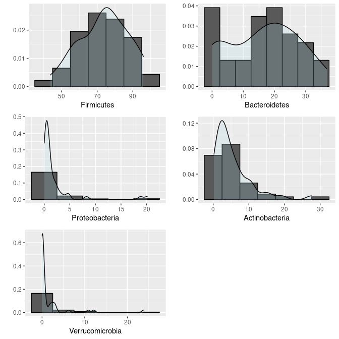

```r
> do.call(grid.arrange, hist.list.meta[1:5])
```

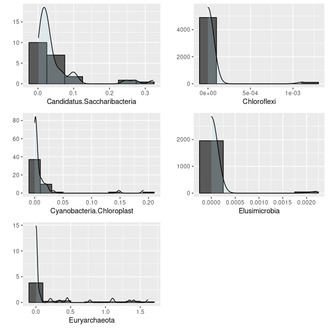

```r
> do.call(grid.arrange, hist.list.meta[6:10])
```

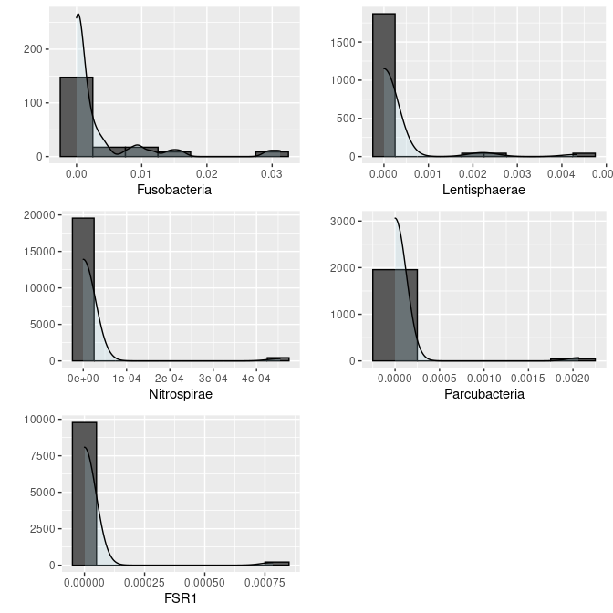

```r
> do.call(grid.arrange, hist.list.meta[11:15])
```

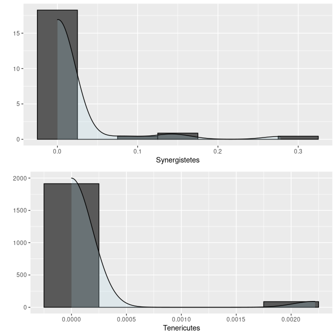

```r
> do.call(grid.arrange, hist.list.meta[16:17])
```

### Univariate analysis

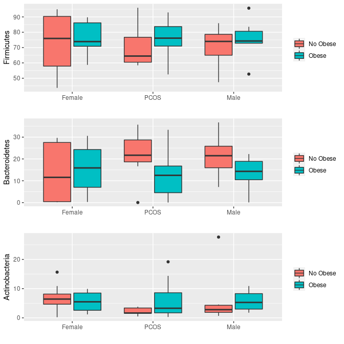

```r
> ### plots
> grid.arrange(bp.interaction[[1]], bp.interaction[[2]], bp.interaction[[4]])
```

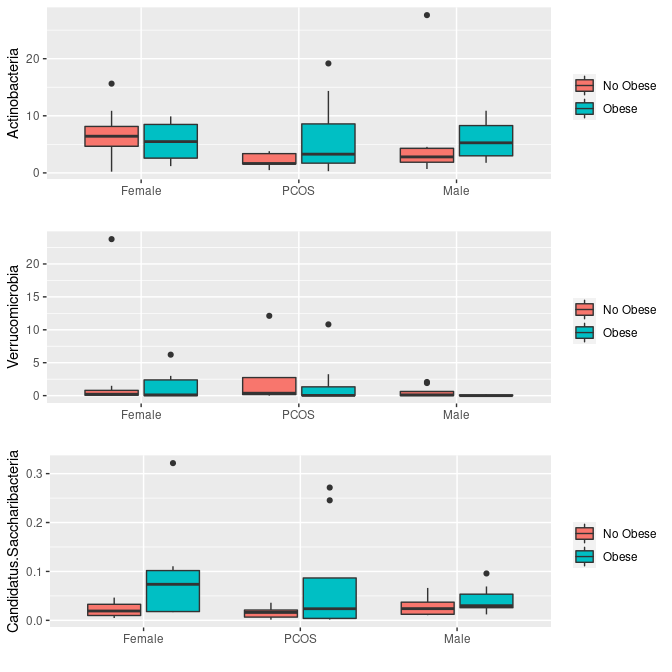

```r
> grid.arrange(bp.interaction[[4]], bp.interaction[[5]], bp.interaction[[6]])
```

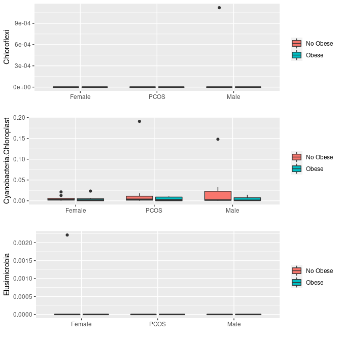

```r
> grid.arrange(bp.interaction[[7]], bp.interaction[[8]], bp.interaction[[9]])
```

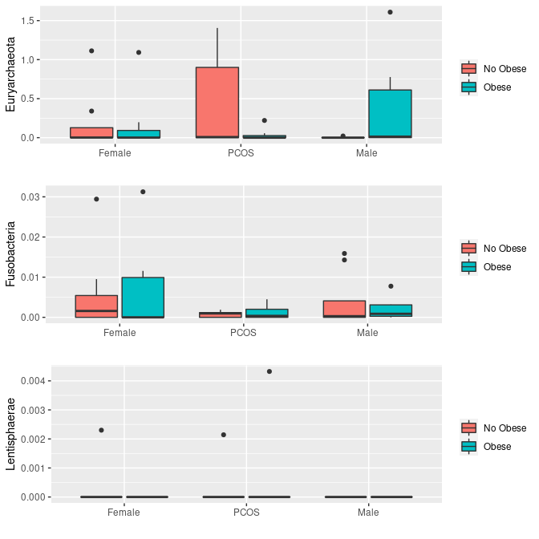

```r
> grid.arrange(bp.interaction[[10]], bp.interaction[[11]], bp.interaction[[12]])
```

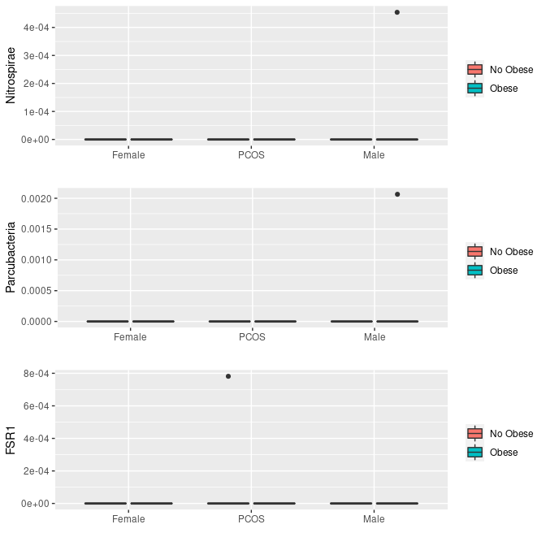

```r
> grid.arrange(bp.interaction[[13]], bp.interaction[[14]], bp.interaction[[15]])
```

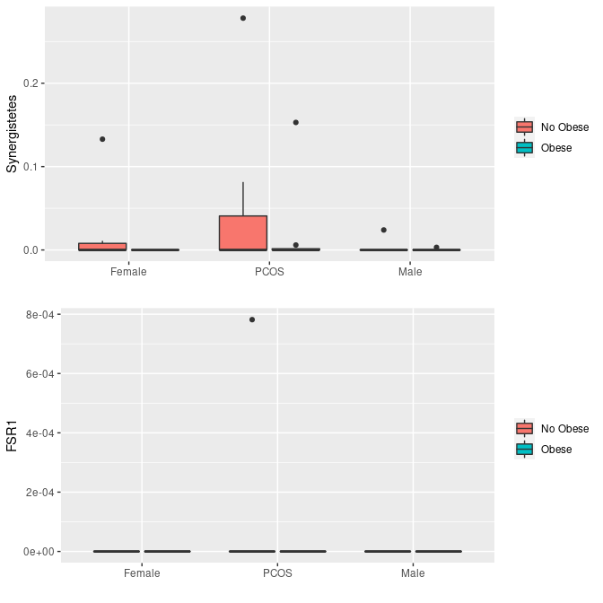

```r
> grid.arrange(bp.interaction[[16]], bp.interaction[[15]])
```

### Multivariate analysis

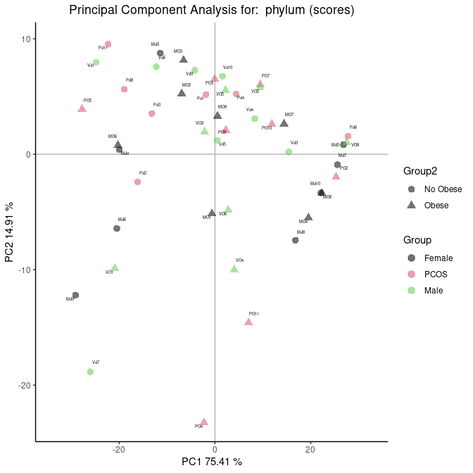

```r
> X <- bacteria_phylum[, 1:17]
> res <- plotPCA_scores(X, factor = list(bacteria_phylum$GROUP, bacteria_phylum$OBESE),
+     title = "phylum (scores)", labels = rownames(bacteria_phylum), center_ = T, scale_ = F)
> res[[2]]
```

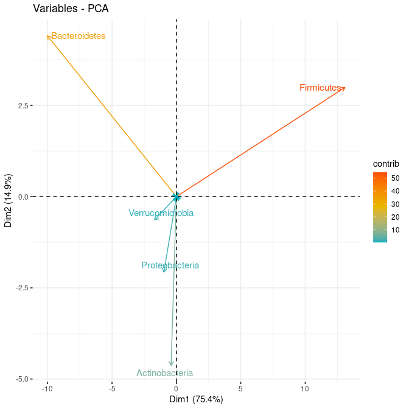

```r
>   fviz_pca_var(res[[1]],
+     col.var = "contrib", # Color by contributions to the PC
+     gradient.cols = c("#00AFBB", "#E7B800", "#FC4E07"),
+
+   repel = TRUE
+ # Avoid text overlapping
+ )
```

## Process genera file

```r
> bacteria_genera.tmp.t <- t(bacteria_genera.tmp)
> colnames(bacteria_genera.tmp.t) <- bacteria_genera.tmp.t[1, ]
> bacteria_genera.tmp.df <- as.data.frame(bacteria_genera.tmp.t[-1, ])
```

```r
> str(bacteria_genera.tmp.df)
```

```
'data.frame':   46 obs. of  283 variables:
 $ Sample                                : chr  "MD03" "MD04" "MD05" "MD06" ...
 $ Abiotrophia                           : chr  "0" "0" "0.00241635388308069" "0" ...
 $ Acetanaerobacterium                   : chr  "0.0226914591868894" "0" "0.00241635388308069" "0.00702777728973769" ...
 $ Acidaminococcus                       : chr  "0" "0" "0.031412600480049" "0" ...
 $ Acidovorax                            : chr  "0" "0" "0" "0" ...
 $ Acinetobacter                         : chr  "0" "0" "0" "0" ...
 $ Actinomyces                           : chr  "0.0390797352663095" "0.0166664021206013" "0.0306071491856887" "0.0316249978038196" ...
 $ Adlercreutzia                         : chr  "0" "0" "0" "0" ...
 $ Aerococcus                            : chr  "0" "0" "0" "0" ...
 $ Aestuariispira                        : chr  "0" "0.00158727639243822" "0" "0" ...
 $ Aggregatibacter                       : chr  "0" "0" "0" "0" ...
 $ Akkermansia                           : chr  "1.19508351717617" "0.298407961778384" "0.478438068849977" "0" ...
 $ Alistipes                             : chr  "0.344153797667822" "1.1174425802765" "0.0120817694154035" "3.48402059138746" ...
 $ Allisonella                           : chr  "0" "0" "0.0249689901251671" "0" ...
```

[output cut: 86 more lines]

```r
> bacteria_genera.tmp.df[, -1] <- apply(bacteria_genera.tmp.df[, -1], 2, as.numeric)
> w <- which(colSums(bacteria_genera.tmp.df[, -1]) == 0)
> ud <- grep("^ud-", colnames(bacteria_genera.tmp.df))
> bacteria_genera <- bacteria_genera.tmp.df[, -ud]
> dim(bacteria_genera)
```

```
[1]  46 214
```

```r
> bacteria_genera$GROUP <- variables_in_bacteria$GROUP
> bacteria_genera$OBESE <- variables_in_bacteria$OBESE
```

```r
> X <- bacteria_genera[, 2:214]
```

```r
> genera.variables <- bacteria_genera  ## remove samples names and order from the summary
>
>
> genera.sum <- genera.variables %>%
+     group_by(GROUP, OBESE) %>%
+     summarise(across(where(is.numeric), resumen), n = n()) %>%
+     mutate_if(is.numeric, format, 4)  # Group the data by variable GROUP and OBESE
>
> d.f <- as.data.frame(t(genera.sum))[c(nrow(t(genera.sum)), 1:(nrow(t(genera.sum)) -
+     1)), ]  # transpose the data for visualization purposes and get rid off the N value for same purposes
>
> # name of each variable.
> nombre_genera_variable <- colnames(genera.variables)[-c(18:19)]
>
> colnames(d.f) <- rep(c("Mean", "SD"), 6)
> d.f_final <- d.f[-c(1:3), ]
> ## ATTENION! Because assining left hand expression is complicated, just for one
> ## table, be careful if we put another data-set For showing the number of
> ## subjects by group
> as.data.frame(d.f_final)
```

```
                                          Mean      SD    Mean      SD    Mean
Abiotrophia                              6e-04   9e-04  0.0013  0.0022   2e-04
Acetanaerobacterium                     0.0117  0.0156  0.0045  0.0061  0.0012
Acidaminococcus                         0.0084  0.0156  0.7027  1.9139  0.0673
Acidovorax                              0.0009  0.0026       0       0       0
Acinetobacter                           0.0004  0.0013       0       0       0
Actinomyces                             0.0297  0.0154  0.0753  0.0925  0.0201
Adlercreutzia                            2e-04   5e-04   2e-04   5e-04   1e-04
Aerococcus                                   0       0   2e-04   5e-04       0
Aestuariispira                           2e-04   6e-04       0       0       0
Aggregatibacter                              0       0       0       0       0
Akkermansia                             2.7154  6.8303  1.1232  1.6917  2.4571
Alistipes                               0.7839  1.2002  0.9815  1.1379  2.7203
Allisonella                             0.0031  0.0088       0       0  0.0072
Alloprevotella                          0.3127  0.8810       0       0  0.5221
Anaerobacter                             1e-04   3e-04       0       0       0
Anaerococcus                            0.0013  0.0016  0.0005  0.0014  0.0008
Anaerofilum                             0.0034  0.0045  0.0023  0.0024  0.0069
Anaerofustis                            0.0014  0.0040  0.0011  0.0013       0
Anaeroglobus                                 0       0       0       0       0
Anaerorhabdus                                0       0       0       0       0
Anaerospora                                  0       0       0       0   2e-04
Anaerosporobacter                            0       0       0       0   2e-04
Anaerostipes                            0.7464  0.7847  0.2680  0.3101  0.6600
Anaerotruncus                           0.0227  0.0197  0.0125  0.0168  0.1542
Anaerovorax                              1e-04   4e-04   4e-04   7e-04       0
Asaccharobacter                         0.0013  0.0031   2e-04   4e-04   2e-04
Atopobium                               0.0020  0.0024  0.0140  0.0124  0.0042
Bacillus                                0.0007  0.0019       0       0   1e-04
Bacteroides                             9.6784 10.7641 11.5552 10.9127  8.7778
Barnesiella                             0.3496  0.6510  0.7901  0.8864  0.6999
Bdellovibrio                                 0       0  0.0006  0.0016       0
Bifidobacterium                         3.7876  3.1955  2.5467  1.7158  0.9263
Bilophila                               0.0449  0.0615  0.0270  0.0258  0.0932
Blautia                                 2.5605  0.9455  1.6278  0.7773  1.4855
Brevibacillus                            3e-04   6e-04       0       0   3e-04
Bulleidia                                    0       0       0       0   1e-04
Burkholderia                            0.0011  0.0023       0       0   1e-04
Buttiauxella                                 0       0       0       0       0
Butyricicoccus                          0.1102  0.0765  0.1999  0.1690  0.2684
```

[output cut: 587 more lines]

```
Subdoligranulum                          3e-04  7e-04
Succinatimonas                          0.0004 0.0011
Succiniclasticum                        0.0772 0.1864
Succinivibrio                           0.0175 0.0462
Sutterella                              0.0582 0.0761
Terrisporobacter                        0.0213 0.0123
Tetragenococcus                              0      0
Turicibacter                            0.0153 0.0163
Vampirovibrio                                0      0
Varibaculum                                  0      0
Veillonella                             0.0514 0.1073
Victivallis                                  0      0
Weeksella                                    0      0
Weissella                               0.0132 0.0338
Yersinia                                0.0083 0.0220
```

```r
> kbl(d.f_final, digits = c(rep(4, 12), 0)) %>%
+     kable_classic_2() %>%
+     add_header_above(c(` ` = 1, `9` = 2, `8` = 2, `9` = 2, `8` = 2, `10` = 2, `9` = 2)) %>%
+     add_header_above(c(` ` = 1, `No Obese` = 2, Obese = 2, `No Obese` = 2, Obese = 2,
+         `No Obese` = 2, Obese = 2)) %>%
+     add_header_above(c(` ` = 1, `Control Females` = 4, PCOS = 4, `Control Males` = 4))
```

[output not shown]

[output cut: 183 more lines]

Let’s investigate which genera are only in one sample

```r
> X <- bacteria_genera[, -c(1, 215, 216)]
> w <- which(colSums(X == 0) == 45)
> rownames(X) <- variables_in_bacteria$Paciente
> X[, w]
```

```
         Acidovorax Aerococcus Aestuariispira Aggregatibacter Anaerorhabdus
MdGLP3  0.000000000  0.0000000    0.000000000     0.000000000   0.000000000
MdGLP4  0.000000000  0.0000000    0.001587276     0.000000000   0.000000000
MdGLP5  0.000000000  0.0000000    0.000000000     0.000000000   0.000000000
MdGLP6  0.000000000  0.0000000    0.000000000     0.000000000   0.000000000
MdGLP7  0.007350386  0.0000000    0.000000000     0.000000000   0.000000000
MdGLP8  0.000000000  0.0000000    0.000000000     0.000000000   0.000000000
MdGLP9  0.000000000  0.0000000    0.000000000     0.000000000   0.000000000
MdGLP10 0.000000000  0.0000000    0.000000000     0.000000000   0.000000000
MOGLP1  0.000000000  0.0000000    0.000000000     0.000000000   0.000000000
MOGLP2  0.000000000  0.0000000    0.000000000     0.000000000   0.000000000
MOGLP3  0.000000000  0.0015075    0.000000000     0.000000000   0.000000000
MOGLP4  0.000000000  0.0000000    0.000000000     0.000000000   0.000000000
MOGLP6  0.000000000  0.0000000    0.000000000     0.000000000   0.000000000
MOGLP7  0.000000000  0.0000000    0.000000000     0.000000000   0.000000000
MOGLP8  0.000000000  0.0000000    0.000000000     0.000000000   0.000000000
MOGLP9  0.000000000  0.0000000    0.000000000     0.000000000   0.000000000
PdGLP1  0.000000000  0.0000000    0.000000000     0.000000000   0.000000000
PdGLP2  0.000000000  0.0000000    0.000000000     0.000000000   0.000000000
PdGLP3  0.000000000  0.0000000    0.000000000     0.000000000   0.000000000
PdGLP4  0.000000000  0.0000000    0.000000000     0.000000000   0.000000000
PdGLP6  0.000000000  0.0000000    0.000000000     0.000000000   0.000000000
PdGLP8  0.000000000  0.0000000    0.000000000     0.000000000   0.000000000
PdGLP11 0.000000000  0.0000000    0.000000000     0.000000000   0.000000000
POGLP2  0.000000000  0.0000000    0.000000000     0.000000000   0.000000000
POGLP3  0.000000000  0.0000000    0.000000000     0.000000000   0.000000000
POGLP4  0.000000000  0.0000000    0.000000000     0.000000000   0.000000000
POGLP5  0.000000000  0.0000000    0.000000000     0.000000000   0.000000000
POGLP7  0.000000000  0.0000000    0.000000000     0.000000000   0.000000000
POGLP8  0.000000000  0.0000000    0.000000000     0.000000000   0.001018143
POGLP10 0.000000000  0.0000000    0.000000000     0.000000000   0.000000000
POGLP11 0.000000000  0.0000000    0.000000000     0.000000000   0.000000000
VdGLP1  0.000000000  0.0000000    0.000000000     0.000000000   0.000000000
VdGLP3  0.000000000  0.0000000    0.000000000     0.000000000   0.000000000
VdGLP4  0.000000000  0.0000000    0.000000000     0.000000000   0.000000000
VdGLP5  0.000000000  0.0000000    0.000000000     0.000000000   0.000000000
VdGLP6  0.000000000  0.0000000    0.000000000     0.006353375   0.000000000
VdGLP7  0.000000000  0.0000000    0.000000000     0.000000000   0.000000000
VdGLP9  0.000000000  0.0000000    0.000000000     0.000000000   0.000000000
VdGLP10 0.000000000  0.0000000    0.000000000     0.000000000   0.000000000
```

[output cut: 556 more lines]

```
VdGLP1   0.00000000 0.000000000 0.00000000
VdGLP3   0.00000000 0.000000000 0.00000000
VdGLP4   0.00000000 0.000000000 0.00000000
VdGLP5   0.00000000 0.000000000 0.00000000
VdGLP6   0.00000000 0.000000000 0.00000000
VdGLP7   0.00000000 0.000000000 0.00000000
VdGLP9   0.00000000 0.000000000 0.00000000
VdGLP10  0.00000000 0.000000000 0.00000000
VOGLP1   0.00000000 0.000000000 0.00000000
VOGLP2   0.00000000 0.000000000 0.00000000
VOGLP3   0.00000000 0.000000000 0.00000000
VOGLP4   0.00000000 0.000000000 0.05822702
VOGLP5   0.00000000 0.000000000 0.00000000
VOGLP6   0.00000000 0.000000000 0.00000000
VOGLP8   0.00000000 0.000000000 0.00000000
```

```r
> rownames(X)[apply(X[, w], 2, function(x) which(x != 0))]
```

```
 [1] "MdGLP7"  "MOGLP3"  "MdGLP4"  "VdGLP6"  "POGLP8"  "PdGLP3"  "PdGLP4"
 [8] "MOGLP3"  "PdGLP6"  "POGLP8"  "MOGLP6"  "MdGLP3"  "PdGLP8"  "VdGLP1"
[15] "MdGLP8"  "MdGLP10" "VdGLP7"  "MOGLP7"  "MdGLP5"  "VOGLP2"  "MdGLP7"
[22] "VOGLP1"  "POGLP4"  "VdGLP5"  "VOGLP4"  "VdGLP1"  "MOGLP6"  "MdGLP7"
[29] "PdGLP2"  "VOGLP4"  "MdGLP7"  "VdGLP7"  "PdGLP4"  "MdGLP8"  "MdGLP3"
[36] "VOGLP5"  "VOGLP5"  "MdGLP8"  "POGLP3"  "PdGLP4"  "MdGLP7"  "VdGLP10"
[43] "VOGLP5"  "MdGLP6"  "VOGLP4"  "PdGLP3"  "VOGLP4"  "MdGLP7"  "PdGLP6"
[50] "MOGLP3"  "VOGLP5"  "POGLP10" "PdGLP8"  "PdGLP4"  "VOGLP4"
```

```r
> X[, -w]
```

```
         Abiotrophia Acetanaerobacterium Acidaminococcus Acinetobacter
MdGLP3  0.0000000000        0.0226914592    0.0000000000   0.000000000
MdGLP4  0.0000000000        0.0000000000    0.0000000000   0.000000000
MdGLP5  0.0024163539        0.0024163539    0.0314126005   0.000000000
MdGLP6  0.0000000000        0.0070277773    0.0000000000   0.000000000
MdGLP7  0.0006682169        0.0000000000    0.0000000000   0.000000000
MdGLP8  0.0000000000        0.0157031888    0.0000000000   0.000000000
MdGLP9  0.0000000000        0.0446548183    0.0000000000   0.003572385
MdGLP10 0.0013806053        0.0013806053    0.0358957367   0.000000000
MOGLP1  0.0000000000        0.0145558053    0.0194077405   0.000000000
MOGLP2  0.0000000000        0.0000000000    0.0000000000   0.000000000
MOGLP3  0.0060299992        0.0000000000    0.0000000000   0.000000000
MOGLP4  0.0000000000        0.0113089479    0.1130894789   0.000000000
MOGLP6  0.0033487375        0.0000000000    5.4383497421   0.000000000
MOGLP7  0.0000000000        0.0012092483    0.0000000000   0.000000000
MOGLP8  0.0000000000        0.0000000000    0.0506858428   0.000000000
MOGLP9  0.0013162744        0.0092139209    0.0000000000   0.000000000
PdGLP1  0.0000000000        0.0000000000    0.0000000000   0.000000000
PdGLP2  0.0000000000        0.0009623805    0.0000000000   0.000000000
PdGLP3  0.0000000000        0.0006301435    0.4713473729   0.000000000
PdGLP4  0.0016016914        0.0056059199    0.0000000000   0.000000000
PdGLP6  0.0000000000        0.0000000000    0.0000000000   0.000000000
PdGLP8  0.0000000000        0.0013291598    0.0000000000   0.000000000
PdGLP11 0.0000000000        0.0000000000    0.0000000000   0.000000000
POGLP2  0.0041244889        0.0000000000    0.0206224443   0.000000000
POGLP3  0.0000000000        0.0000000000    0.0000000000   0.000000000
POGLP4  0.0008239133        0.0000000000    0.0000000000   0.000000000
POGLP5  0.0000000000        0.0000000000    0.8488289178   0.000000000
POGLP7  0.0000000000        0.0000000000    0.0008564357   0.000000000
POGLP8  0.0000000000        0.0010181433    0.1069050480   0.000000000
POGLP10 0.0073044018        0.0000000000    0.0000000000   0.000000000
POGLP11 0.0000000000        0.0000000000    0.0000000000   0.000000000
VdGLP1  0.0000000000        0.0067604110    0.3130070308   0.000000000
VdGLP3  0.0000000000        0.0000000000    0.0138683432   0.000000000
VdGLP4  0.0000000000        0.0029723644    1.4178178386   0.000000000
VdGLP5  0.0000000000        0.0000000000    0.0000000000   0.000000000
VdGLP6  0.0000000000        0.0000000000    0.0000000000   0.000000000
VdGLP7  0.0000000000        0.0000000000    0.0000000000   0.000000000
VdGLP9  0.0037218165        0.0059549065    0.0014887266   0.000000000
VdGLP10 0.0000000000        0.0120731937    0.0000000000   0.000000000
```

[output cut: 1637 more lines]

```
VdGLP1  0.000000000 0.000000000
VdGLP3  0.000000000 0.000000000
VdGLP4  0.000000000 0.000000000
VdGLP5  0.000000000 0.000000000
VdGLP6  0.000000000 0.000000000
VdGLP7  0.000000000 0.006602621
VdGLP9  0.000000000 0.116120676
VdGLP10 0.000000000 0.000000000
VOGLP1  0.000000000 0.000000000
VOGLP2  0.000000000 0.000000000
VOGLP3  0.000000000 0.089775261
VOGLP4  0.000000000 0.001512390
VOGLP5  0.000000000 0.000000000
VOGLP6  0.000000000 0.000000000
VOGLP8  0.000000000 0.001173000
```

```r
> d.f_means <- d.f_final[, c(1, 3, 5, 7, 9, 11)]
> d.f_means.num <- as.data.frame(apply(d.f_means, 2, as.numeric))
> d.f_genera <- as.data.frame(rowSums(d.f_means.num))
> d.f_genera$genero <- rownames(d.f_means)
> colnames(d.f_genera) <- c("abundance", "genero")
> d.f_genera.ti <- as_tibble(d.f_genera)
> d.f_genera.ti %>%
+     arrange(abundance)
```

```
# A tibble: 213 × 2
   abundance genero
       <dbl> <chr>
 1    0.0001 Anaerorhabdus
 2    0.0001 Butyrivibrio
 3    0.0001 Candidatus Carsonella
 4    0.0001 Devosia
 5    0.0001 Halomonas
 6    0.0001 Kocuria
 7    0.0001 Leclercia
 8    0.0001 Limnohabitans
 9    0.0001 Massilia
10    0.0001 Morococcus
# … with 203 more rows
```

```r
> colnames(bacteria_genera) <- gsub(" ", "_", colnames(bacteria_genera))
> variables <- colnames(bacteria_genera)
>
> hist.list.meta <- list()  ## initizalize a list of the histogram
> ## plot all histograms via loop for(i in 1:length(variables)){
> ## if(variables[i]=='Order'||variables[i]=='Sample'){ next }else
> ## if(class(bacteria_genera[,i])=='factor'){ next } variable <- variables[i] ##
> ## name of the variable to plot titulo <- colnames(bacteria_genera)[i] # title
> ## of the varialbe breaks <- pretty(range(bacteria_genera[,variable]), n =
> ## nclass.Sturges(bacteria_genera[,variable]), min.n = 1)# make pretty
> ## histogram by appropiate bins bwidth <- breaks[2]-breaks[1] ## bin width ##
> ## plot
> ## hist.list.meta[[i]]<-ggplot(bacteria_genera,aes_string(x=variable))+geom_histogram(aes(y=..density..),
> ## binwidth =bwidth,colour='black')+geom_density(alpha=.2,
> ## fill='lightblue')+xlab(titulo)+ylab('') }
>
>
> bp.interaction <- list()  ## intialize boxplot list interaction
> for (i in 1:length(variables)) {
+     if (class(variables[i]) == "factor") {
+         next
+     }
+     titulo <- colnames(bacteria_genera)[i]
+     variable <- variables[i]
+     bp.interaction[[variables[i]]] <- ggplot(bacteria_genera, aes_string(x = bacteria_genera$GROUP,
+         y = variable, interaction(bacteria_genera$GROUP), fill = bacteria_genera$OBESE)) +
+         geom_boxplot() + ylab(titulo) + xlab("") + theme(legend.title = element_blank())
+
+ }
```

```r
> grep("faeca", variables, ignore.case = T)
```

```
[1] 86 87 88
```

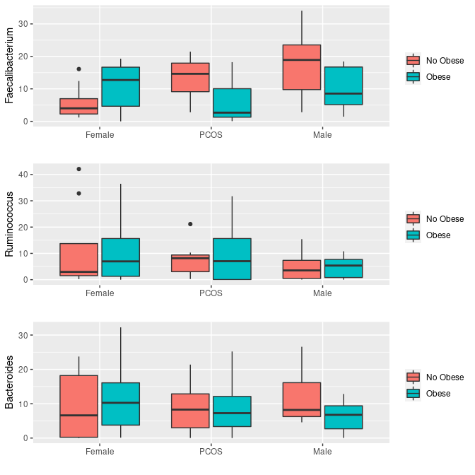

```r
> grid.arrange(bp.interaction[["Faecalibacterium"]], bp.interaction[["Ruminococcus"]],
+     bp.interaction[["Bacteroides"]])
```

```r
> X <- bacteria_genera[, -c(1, 215, 216)]
```

```r
> grupos <- list(variables_in_bacteria$GROUP, variables_in_bacteria$OBESE)
```

Because we are leading with more variables than observations, we are going to perform three approaches. 1. Simply by computing a PCA on the traspose data (prcomp and princomp) 2. Nipals algorithm 3. Sparse PCA

### prcomp and princomp

```r
> pcxt <- prcomp(t(X), center = T, scale = F)
> list.pcxt <- list(scores = pcxt$rot, loadings = pcxt$x, var = 100 * pcxt$sdev^2/sum(pcxt$sdev^2))
```

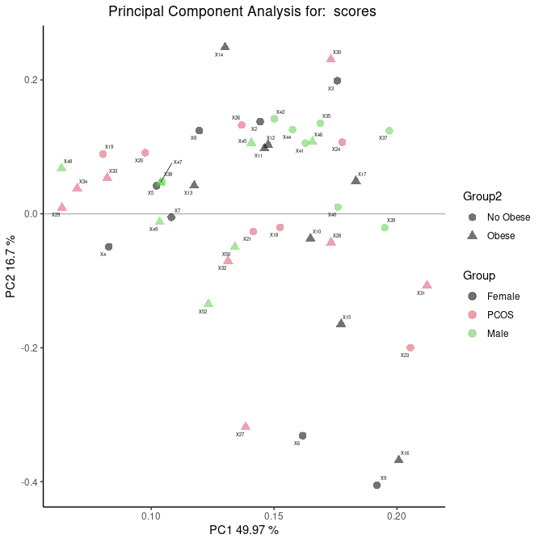

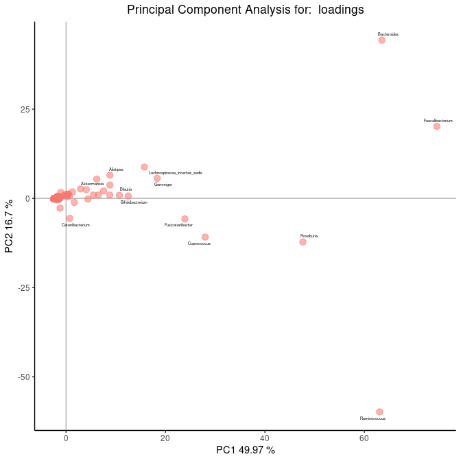

```r
> graficos <- plotPCA_methods(list.pcxt, factor = grupos, title1 = "scores ", title2 = "loadings",
+     labels.scores = rownames(X), labels.loads = colnames(X))
> graficos
```

```r
> # graficos[[2]]
```

### NIPALS

```r
> n <- nrow(X)
> pcx.nipals <- chemometrics::nipals(X, a = ncol(X), it = 200)
```

[output not shown]

[output cut: 2914 more lines]

[output not shown]

```r
> pcx.nipals_variance <- 100 * diag(t(pcx.nipals$T) %*% pcx.nipals$T)/sum(diag(t(pcx.nipals$T) %*%
+     pcx.nipals$T))
> list.nipals_1 <- list(scores = pcx.nipals$T, loadings = pcx.nipals$P, varianza = pcx.nipals_variance)
```

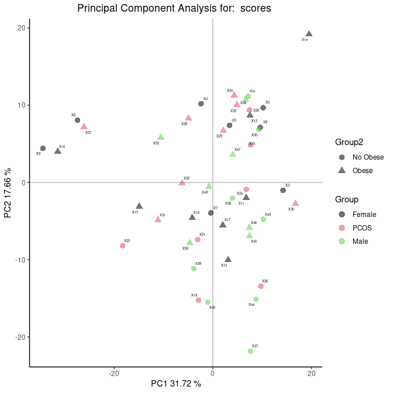

```r
> graficos <- plotPCA_methods(list.nipals_1, factor = grupos, title1 = "scores ", title2 = "loadings",
+     labels.scores = rownames(X), labels.loads = colnames(X))
> graficos[[1]]
```

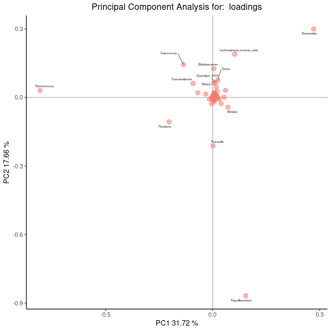

```r
> graficos[[2]]
```

### Sparse PCA

Let’s create a function to fix beta andcontrol sparsity.

```r
> perf <- function(X, X.pred) {
+
+     return(abs(norm(X - X.pred, type = "F"))/norm(X, type = "F"))
+
+ }
>
> spca.perf <- function(X, fix_parameter, transpose, scale.) {
+
+     parameter <- seq(1e-10, 1, 0.01)
+     perf.vector <- vector(mode = "numeric", length = length(parameter))
+     if (fix_parameter == "alpha") {
+
+         beta <- parameter
+         alpha <- 1e-04
+         if (transpose == F) {
+
+             for (i in 1:length(parameter)) {
+                 perf.vector[i] <- perf(as.matrix((X)), t(spca((X), alpha = alpha,
+                   beta = beta[i], center = T, scale = scale., verbose = F, k = ncol(X))$loadings))
+
+             }
+             beta <- beta[which.min(perf.vector)]
+             pcx <- spca(X, alpha = alpha, beta = beta, verbose = F, center = T, scale = scale.,
+                 k = ncol(X))
+
+         } else if (transpose == T) {
+
+             for (i in 1:length(parameter)) {
+                 perf.vector[i] <- perf(as.matrix(t(X)), (spca(t(X), alpha = alpha,
+                   beta = beta[i], verbose = F, center = T, scale = scale., k = ncol(X))$scores))
+
+             }
+             beta <- beta[which.min(perf.vector)]
+             pcx <- spca(t(X), alpha = alpha, beta = beta, verbose = F, center = T,
+                 scale = scale., k = ncol(X))
+         }
+
+     } else if (fix_parameter == "beta") {
+
+         alpha <- parameter
+         beta <- 1e-04
+         if (transpose == F) {
+
+             for (i in 1:length(parameter)) {
+                 perf.vector[i] <- perf(as.matrix((X)), t(spca((X), alpha = alpha[i],
+                   beta = beta, center = T, scale = scale., verbose = F, k = ncol(X))$loadings))
+
+             }
+             alpha <- alpha[which.min(perf.vector)]
+             pcx <- spca(X, alpha = alpha, beta = beta, verbose = F, center = T, scale = scale.,
+                 k = ncol(X))
+         } else if (transpose == T) {
+
+             for (i in 1:length(parameter)) {
+                 perf.vector[i] <- perf(as.matrix(t(X)), (spca(t(X), alpha = alpha[i],
+                   center = T, scale = scale., beta = beta, verbose = F, k = ncol(X))$scores))
+
+             }
+
+             alpha <- alpha[which.min(perf.vector)]
+             pcx <- spca(t(X), alpha = alpha, beta = beta, center = T, scale = scale.,
+                 verbose = F, k = ncol(X))
+         }
+
+
+     }
+
+     return(pcx)
+ }
```

```r
> pcx.a <- spca.perf(X, "beta", transpose = F, scale. = T)
> pcx.a.t <- spca.perf(X, "beta", transpose = T, scale. = T)
> pcx.b <- spca.perf(X, "alpha", transpose = F, scale. = T)
> pcx.b.t <- spca.perf(X, "alpha", transpose = T, scale. = F)
```

```r
> lista.spca.b <- list(loadings = (pcx.b$loadings), scores = t(pcx.b$scores), var = 100 *
+     round(pcx.b$eigenvalues/sum(pcx.b$eigenvalues), 2))
> lista.spca.b.t <- list(loadings = (pcx.b.t$scores), scores = pcx.b.t$loadings, var = 100 *
+     round(pcx.b.t$eigenvalues/sum(pcx.b.t$eigenvalues), 2))
>
>
> lista.spca.a <- list(loadings = (pcx.a$loadings), scores = t(pcx.a$scores), var = 100 *
+     round(pcx.a$eigenvalues/sum(pcx.a$eigenvalues), 2))
> lista.spca.a.t <- list(loadings = (pcx.a.t$scores), scores = pcx.a.t$loadings, var = 100 *
+     round(pcx.a.t$eigenvalues/sum(pcx.a.t$eigenvalues), 2))
```

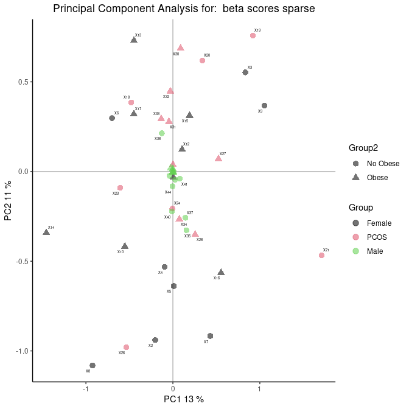

```r
> g1 <- plotPCA_methods(lista.spca.b, grupos, title1 = "beta scores sparse", title2 = "beta loads sparse",
+     labels.loads = colnames(X), labels.scores = rownames(X))
> g1[[1]]
```

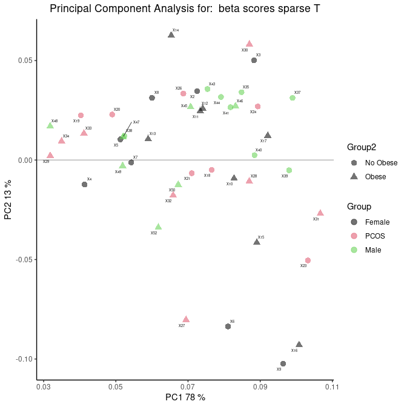

```r
> g2 <- plotPCA_methods(lista.spca.b.t, grupos, title1 = "beta scores sparse T", title2 = "beta loads sparse T",
+     labels.loads = colnames(X), labels.scores = rownames(X))
>
> g2[[1]]
```